# Cell Culture and Activation

Ramon Massoni-Badosa

10/17/2019

# 1 Introduction

The objective of this notebook is to elucidate if culturing and activating PBMC after thawing them removes the technical artifacts introduced by sampling time.

# 2 Pre-processing

## 2.1 Package loading

```r
library(scater)
library(scran)
library(Seurat)
library(ggpubr)
library(kBET)
library(cluster)
library(AnnotationDbi)
library(org.Hs.eg.db)
library(viridis)
library(tidyverse)
```

## 2.2 Source script with functions

```r
source("bin/utils.R")
```

## 2.3 Load data

```r
t_act_l <- readRDS("results/R_objects/t_act_Seurat_list_annotated")
dea_list <- readRDS("../2-CLL/results/R_objects/dea_results_per_patient.rds")
```

## 2.4 Merge Seurat object

```r
t_act <- merge(
  x = t_act_l$`0M`,
  y = c(t_act_l$`0F`, t_act_l$`2M` ,t_act_l$`2F`),
  add.cell.ids = c("0M", "0F", "2M", "2F")
)
t_act <- pre_process_seurat(t_act)
```

# 3 Effect Cell Culture

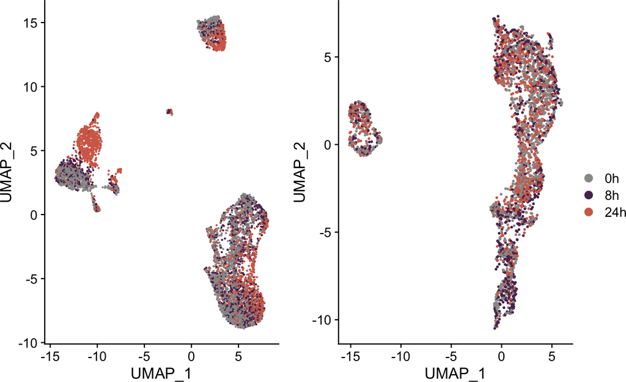

```r
t_act_l <- purrr::map(t_act_l, RunTSNE, reduction = "pca", dims = 1:15)
t_act_l <- purrr::map(t_act_l, function(seurat) {
  seurat$time <- factor(seurat$time, levels = c("0h", "8h", "24h"))
  Idents(seurat) <- "time"
  seurat
})
t_act_umaps <- purrr::map(t_act_l, function(seurat) {
  DimPlot(seurat, reduction = "umap", cols = c("#999999", "#58315E", "#D36A55"))
})
# saveRDS(t_act_umaps, "results/R_objects/ggplots/umaps_t_activation.rds")
t_act_tsnes <- purrr::map(t_act_l, function(seurat) {
  DimPlot(seurat, reduction = "tsne", cols = c("#999999", "#58315E", "#D36A55"))
})
# saveRDS(t_act_tsnes, "results/R_objects/ggplots/tsnes_t_activation.rds")
male_arranged <- ggarrange(
  plotlist = t_act_umaps[c("0M", "2M")],
  nrow = 1,
  ncol = 2,
  common.legend = TRUE,
  legend = "right"
)
male_arranged
```

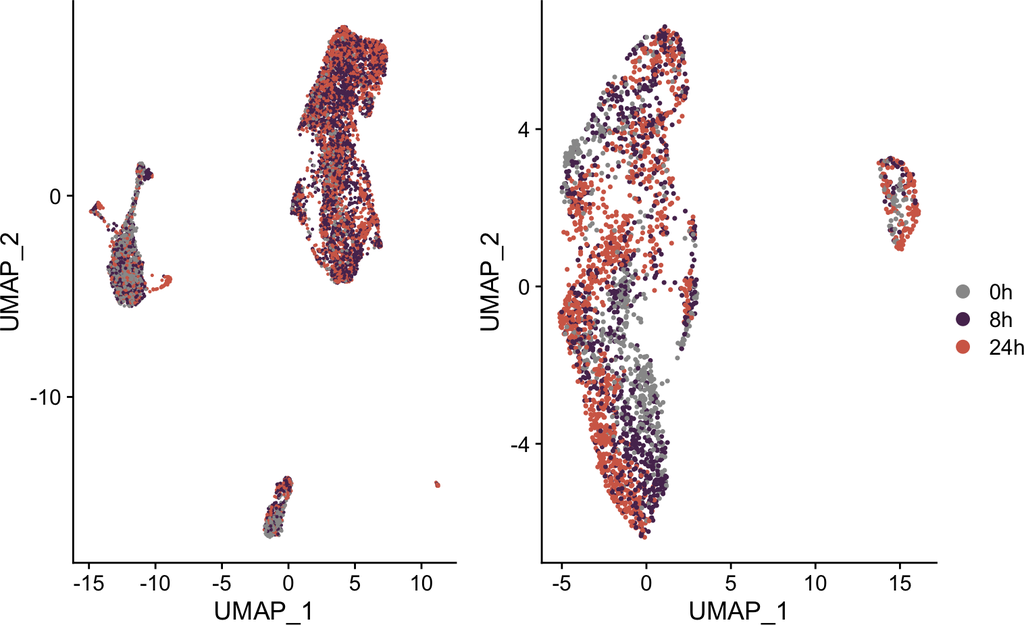

```r
female_arranged <- ggarrange(
  plotlist = t_act_umaps[c("0F", "2F")],
  nrow = 1,
  ncol = 2,
  common.legend = TRUE,
  legend = "right"
)
female_arranged
```

Interestingly, we can observe how culturing and activating PBMC from the male donor for two days (day 2) removed the cold-shock stress response, because we observe a high intermixing between time-points as compared to the control (not-cultured, day 0). On the contrary, we do not observe this for the female donor, as in the cultured PBMC we still observe the effect of time. This donor is invalidated by the fact that the control dataset (not cultured PBMC, day 0) does not display the typical gradient of time that we have observed multiple times before. We could think that the samples are mislabeled, so Day 0 and 2 could be interchanged. However, the fact that in cultured dataset we do not detect monocytes (similar to the male donor), rules out this scenario. All in all, we exclude the female dataset; whilst the male dataset points to promising results. We will need to repeat this same experiment with two more donors to see if the observation that culturing removes the technical artifact introduced by time is reproducible.

## 3.1 kBET

The former analysis provides qualitative information about the intermixing between time-points. To get a quantitative view, we will use [kBET](https://www.nature.com/articles/s41592-018-0254-1):

```
## Initial neighbourhood size is set to 761.
## reducing dimensions with svd first...
## finding knns...done. Time:
##    user  system elapsed
##   3.238   0.031   3.276
## KNN input is a list, extracting nearest neighbour index.
```

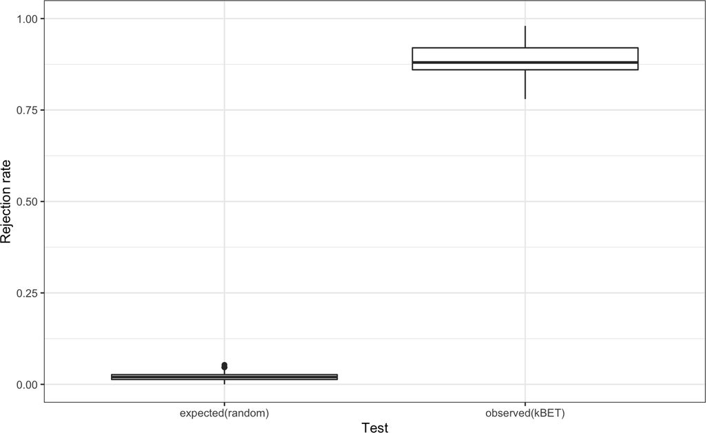

```
## Initial neighbourhood size is set to 843.
## reducing dimensions with svd first...
## finding knns...done. Time:
##    user  system elapsed
##   4.350   0.038   4.401
## KNN input is a list, extracting nearest neighbour index.
```

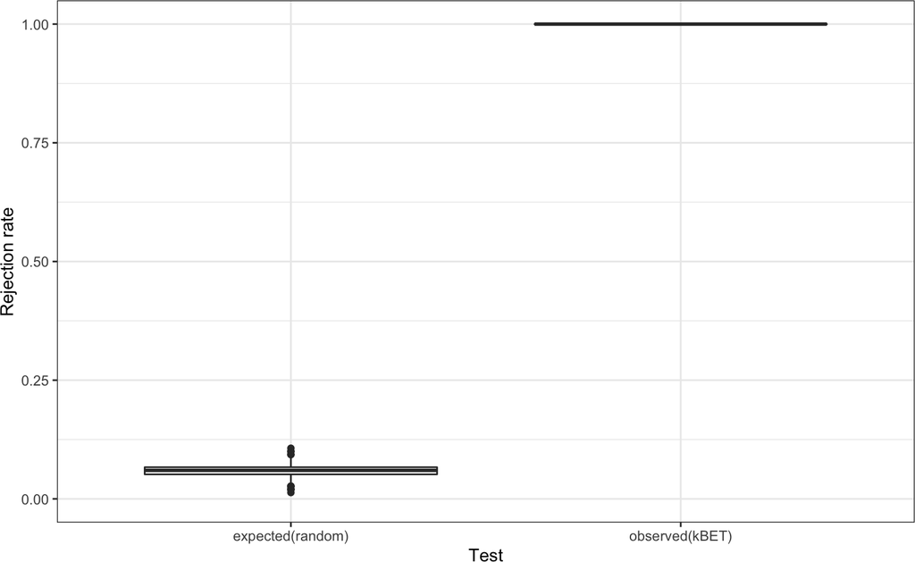

```
## Initial neighbourhood size is set to 402.
## reducing dimensions with svd first...
## finding knns...done. Time:
##    user  system elapsed
##   0.579   0.009   0.589
## KNN input is a list, extracting nearest neighbour index.
```

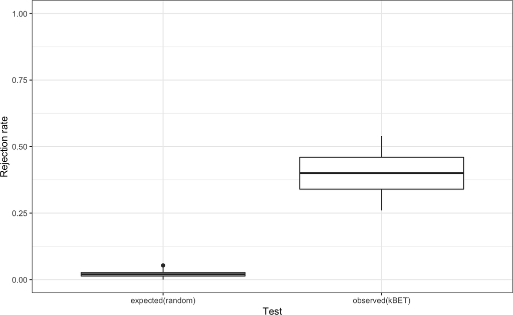

```
## Initial neighbourhood size is set to 338.
## reducing dimensions with svd first...
## finding knns...done. Time:
##    user  system elapsed
##   0.366   0.005   0.372
## KNN input is a list, extracting nearest neighbour index.
```

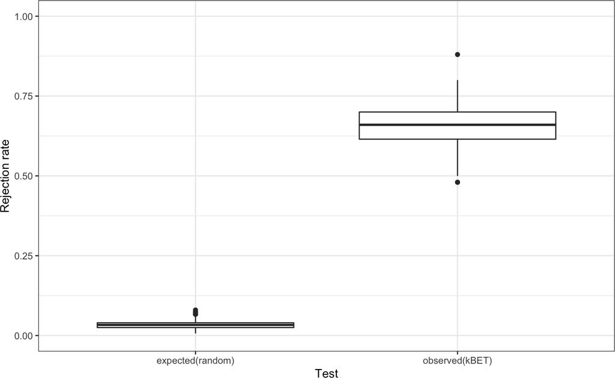

```r
t_act_male <- t_act_l[c("0M", "2M")]
# saveRDS(t_act_male, "results/R_objects/t_act_Seurat_male1.rds")
acceptance_rates_l <- purrr::map(t_act_l, function(seurat) {
  seurat$is_biased <- ifelse(seurat$time == "0h", FALSE, TRUE)
  seurat <- pre_process_seurat(seurat)
  DimPlot(seurat, reduction = "umap")
  mat <- as.matrix(seurat@reductions$umap@cell.embeddings)
  batch <- seurat$is_biased
  batch_estimate <- kBET(mat, batch = batch, verbose = TRUE, heuristic = FALSE, testSize = 50)
  batch_results <- batch_estimate$results
  batch_results <- batch_results %>%
    dplyr::mutate(cell_type = seurat$cell_type) %>%
    dplyr::filter(tested == 1) %>%
    dplyr::group_by(cell_type) %>%
    dplyr::summarise(acceptance_rate = mean(kBET.pvalue.test > 0.05) * 100)
  batch_results
})
```

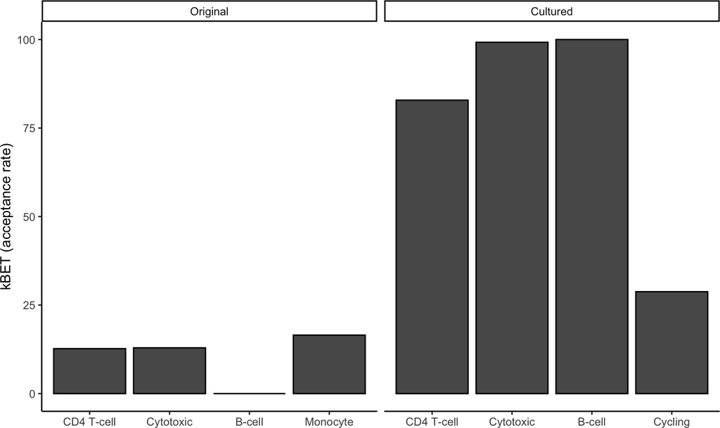

```r
acceptance_rates_l$`0M` <- acceptance_rates_l$`0M` %>%
  dplyr::filter(cell_type %in% c("B", "CD4 T", "Cytotoxic", "Monocyte")) # DC not enough cells
acceptance_rates_m <- bind_rows(acceptance_rates_l[c("0M", "2M")], .id = "day")
acceptance_rates_m$cell_type[acceptance_rates_m$cell_type == "CD4 T"] <- "CD4 T-cell"
acceptance_rates_m$cell_type[acceptance_rates_m$cell_type == "B"] <- "B-cell"
acc_rate_m_gg <- acceptance_rates_m %>%
  dplyr::mutate(cell_type = factor(cell_type, levels = c("CD4 T-cell", "Cytotoxic", "B-cell", "Monocyte", "Cycling"))) %>%
  dplyr::mutate(day = ifelse(day == "0M", "Original", "Cultured")) %>%
  dplyr::mutate(day = factor(day, levels = c("Original", "Cultured"))) %>%
  ggplot(aes(cell_type, acceptance_rate)) +
    geom_col(color = "black") +
    scale_y_continuous(limits = c(0, 100)) +
    labs(x = "", y = "kBET (acceptance rate)") +
    facet_grid(. ~ day, scales = "free_x") +
    theme_classic()
acc_rate_m_gg
```

```r
# saveRDS(acc_rate_m_gg, "results/R_objects/ggplots/barplot_kBET_t_act.rds")
# saveRDS(t_act_l$`2M`, "results/R_objects/t_act_seurat_2M.rds")

# day <- c("Original", "Cultured")
# acceptance_rates_m <- data.frame(
#   day = factor(day, levels = day),
#   acceptance_rate = acceptance_rates_l[c("0M", "2M")]
# )
# acc_rate_m_gg <- ggplot(acceptance_rates_m, aes(day, acceptance_rate)) +
#   geom_col(color = "black") +
#   scale_y_continuous(limits = c(0, 100)) +
#   labs(x = "", y = "kBET (acceptance rate)") +
#   theme_classic()
# acc_rate_m_gg
# acceptance_rates_f <- bind_rows(acceptance_rates_l[c("0F", "2F")], .id = "day")
# acceptance_rates_f$day <- c("Day 0", "Day 2")
# acc_rate_f_gg <- ggplot(acceptance_rates_f, aes(day, acceptance_rate)) +
#   geom_col(color = "black") +
#   scale_y_continuous(limits = c(0, 100)) +
#   labs(x = "", y = "kBET (acceptance rate)") +
#   theme_classic()
# saveRDS(acc_rate_m_gg, "results/R_objects/ggplots/barplot_kBET_t_act.rds")
#
# acceptance_rates_gg <- purrr::map(acceptance_rates_l, function(df) {
#   ggplot(df, aes(fct_reorder(cell_type, acceptance_rate), acceptance_rate)) +
#     geom_col(color = "black") +
#     scale_y_continuous(limits = c(0, 100)) +
#     labs(x = "", y = "kBET (acceptance rate)") +
#     theme_classic() +
#     coord_flip()
# })
# DimPlot(object = t_act_l$`2M`, reduction = "umap")
```

# 4 Cold-shock Score

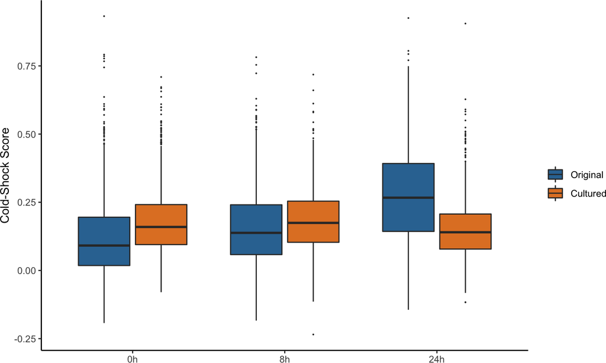

```r
# Find cold shock signature
cold_shock_signature <- readRDS("../1-PBMC/results/R_objects/cold_shock_signature_up.rds")

# Compute cold shock score
t_act_l <- purrr::map(t_act_l, function(seurat) {
  seurat <- AddModuleScore(
    object = seurat,
    features = list(cold_shock_signature),
    name = "cold_shock_score"
  )
  seurat
})

# Visualize cold-shock score
cold_shock_df <- t_act_l[c("0M", "2M")] %>%
  map(~ .x@meta.data) %>%
  map(~ .x %>% dplyr::select("day", "time", "cold_shock_score1")) %>%
  bind_rows(.id = "condition") %>%
  mutate(condition = ifelse(condition == "0M", "Original", "Cultured")) %>%
  mutate(condition = factor(condition, levels = c("Original", "Cultured")))
cold_shock_violin <- cold_shock_df %>%
  ggplot(aes(time, cold_shock_score1, fill = condition)) +
    geom_boxplot(outlier.size = 0.1) +
    labs(x = "", y = "Cold-Shock Score", fill = "") +
    scale_fill_manual(values = c("#3374A1", "#E1812C")) +
    theme_classic()
cold_shock_violin
```

```r
# saveRDS(cold_shock_violin, "results/R_objects/ggplots/boxplot_cold_shock_t_act.rds")




# # Visualize cold-shock-score
# violins_gg <- purrr::map(t_act_l, function(seurat) {
#   violin_cold_shock_score <- VlnPlot(
#     seurat,
#     features = "cold_shock_score1",
#     pt.size = 0,
#     group.by = "time",
#     cols = c("#999999", "#58315E", "#D36A55")
#   )
#   violin_cold_shock_score
# })
# male_violins <- ggarrange(
#   plotlist = violins_gg[c("0M", "2M")],
#   nrow = 1,
#   ncol = 2,
#   common.legend = TRUE,
#   legend = "right"
# )
# male_violins
# female_violins <- ggarrange(
#   plotlist = violins_gg[c("0F", "2F")],
#   nrow = 1,
#   ncol = 2,
#   common.legend = TRUE,
#   legend = "right"
# )
# female_violins
```